# Introduction to R

# Scatter plots

Scatter plots visualize the covariation of two variables, both typically continuous.

Specify two variables to `plot()` to produce a scatter plot:

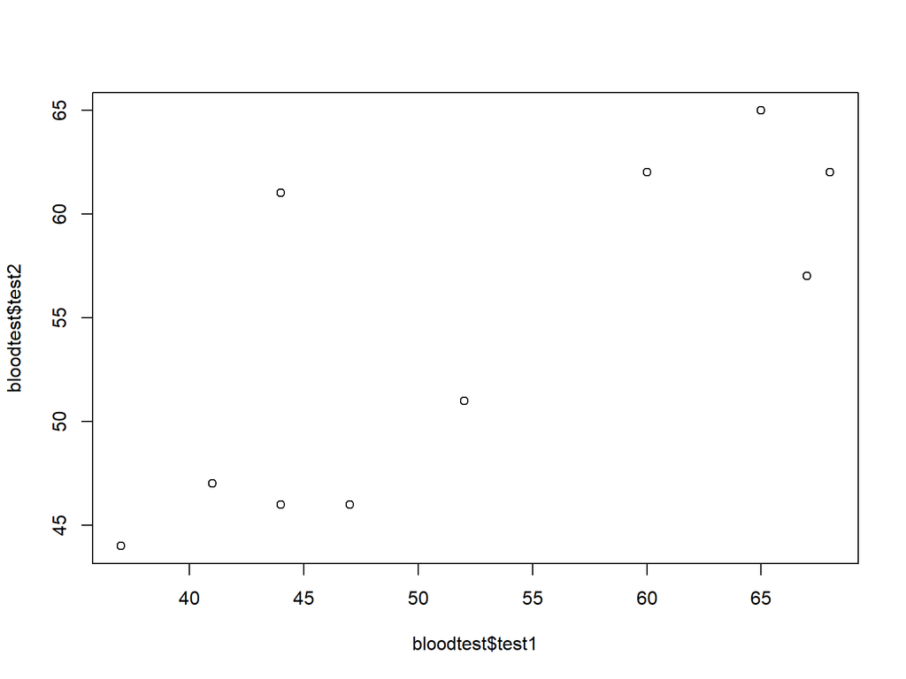

Fig 1. scatterplot of test1 vs test2

```r
plot(bloodtest$test1, bloodtest$test2)
```

Changing the axis labels and adding a title are easy with `xlab=`, `ylab=`, and `main=`:

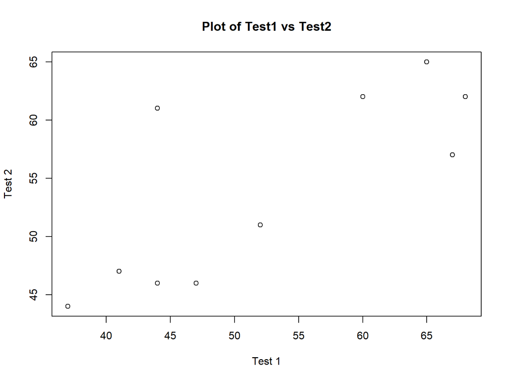

Fig 2. changing titles

```r
plot(bloodtest$test1, bloodtest$test2,
     xlab="Test 1",
     ylab="Test 2",
     main="Plot of Test1 vs Test2")
```

We can change the color of the symbols with `col=` and the shape of the symbols with `pch=`.

- Run the function `colors()` to see a list of color names
- See `?pch` for a list of plotting symbols

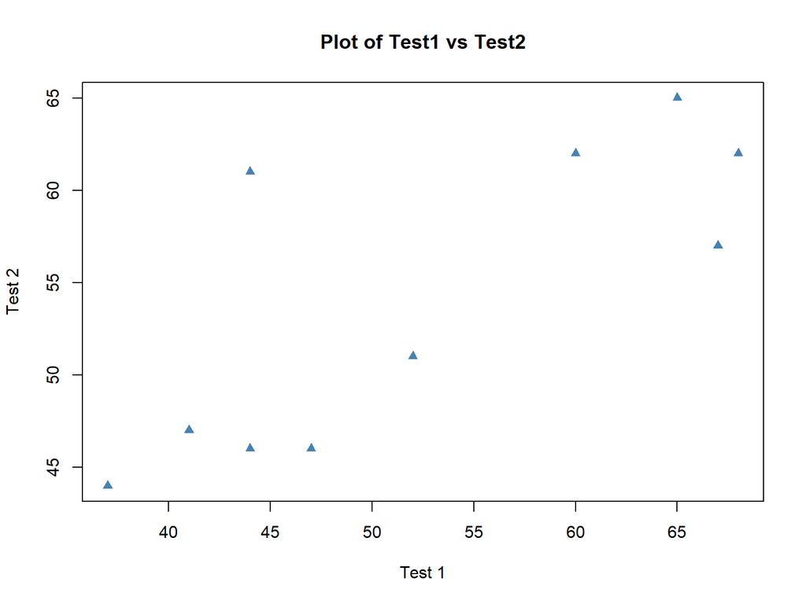

Fig 3. changing shapes and colors

```r
plot(bloodtest$test1, bloodtest$test2,
     xlab="Test 1",
     ylab="Test 2",
     main="Plot of Test1 vs Test2",
     col="steelblue",
     pch=17)
```

> Create a scatter plot of the `dat_csv` variables `read` (x-axis) and `write` (y-axis). Change the shape of the symbols to solid squares and their color to red.

# Histograms

Histograms display the distributions of continuous variables.

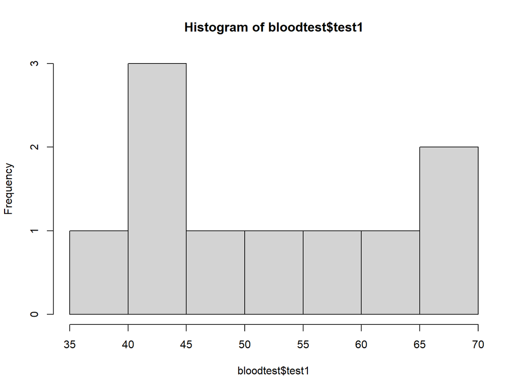

Fig 4. histogram

```r
hist(bloodtest$test1)
```

# Boxplots

Boxplots are often used to compare the distribution of a continuous variable across the levels of a categorical variable.

Use formula notation in `boxplot()` to specify boxplots of the variable on the left side of `~` by the variable on the right side.

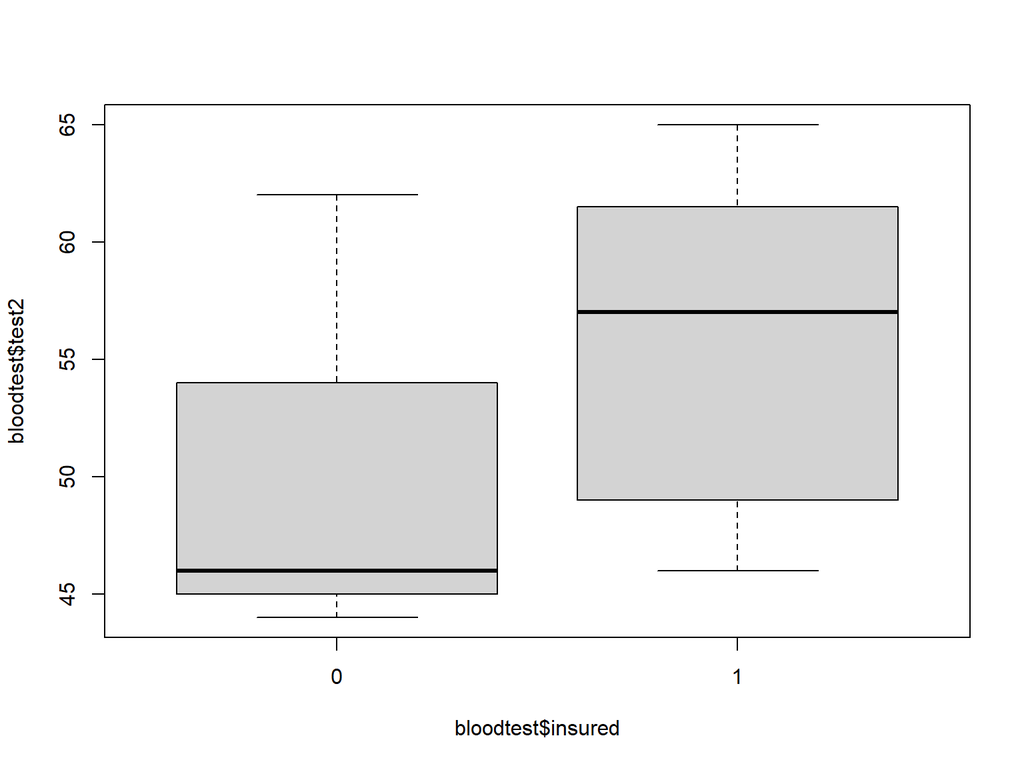

Fig 5. boxplots of test2 by insured

```r
boxplot(bloodtest$test2 ~ bloodtest$insured)
```

The `R` plotting functions share many of the same arguments. Here we use `xlab=`, `ylab=`, and `main=` again to change the titles, and `col=` to change the fill color of the boxes.

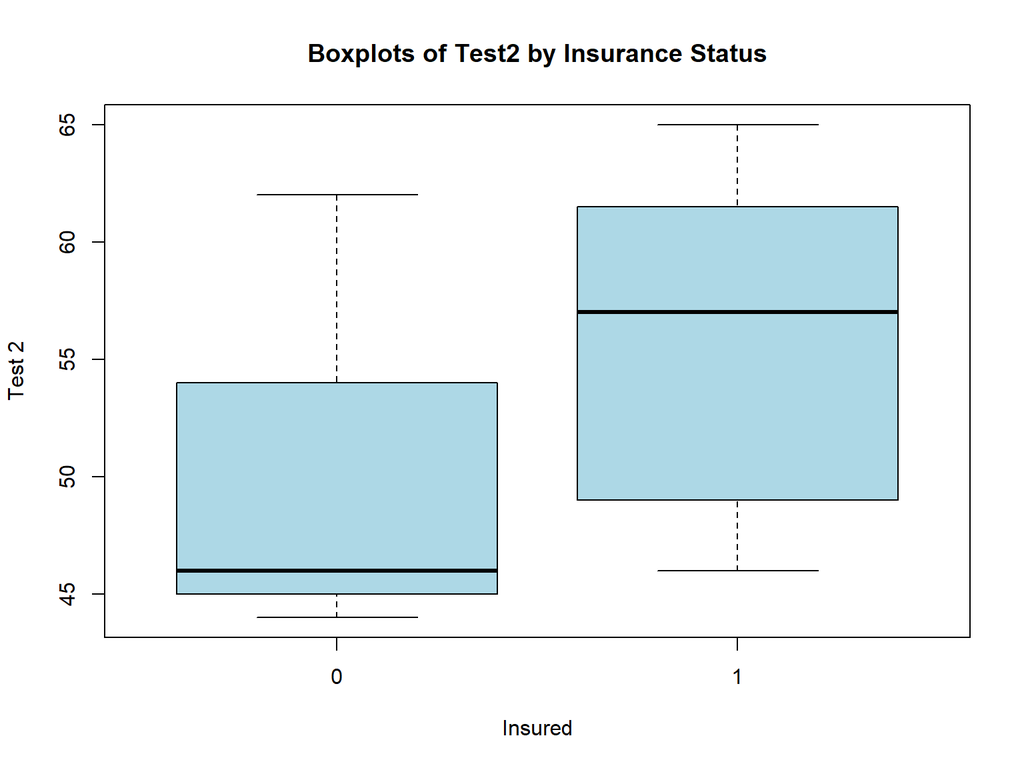

Fig 6. boxplots new titles

```r
boxplot(bloodtest$test2 ~ bloodtest$insured,
        xlab="Insured",
        ylab="Test 2",
        main = "Boxplots of Test2 by Insurance Status",
        col="lightblue")
```

# Barplots

One common use of bar plots is to visualize the frequencies of levels of grouping variables, where the height of the bar represents the number of observations falling into that grouping.

We can thus think of bar plots as graphical representations of frequency tables.

`R` makes this connection explicit by allowing the output of `table()` to be used as the input to `barplot()`.

For example, let’s plot the frequencies of groupings made by the variables `gender` and `hospital`. We add a legend to the plot with `legend.text=TRUE`.

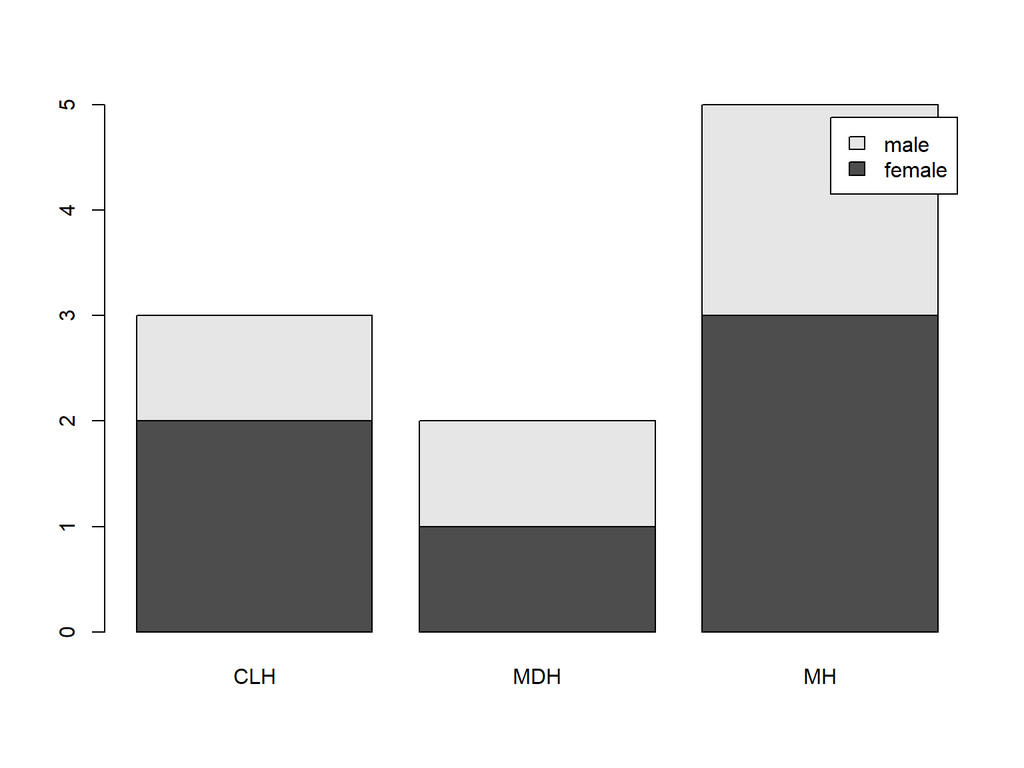

Fig 7. barplot of gender by hospital

```r
tab <- table(bloodtest$gender, bloodtest$hospital)
barplot(tab,
        legend.text = TRUE)
```

Now let’s request side-by-side bars instead of stacked bars with `beside=TRUE`:.

We also use `col=` again to color the bars, but now we have 2 colors to specify as a vector:

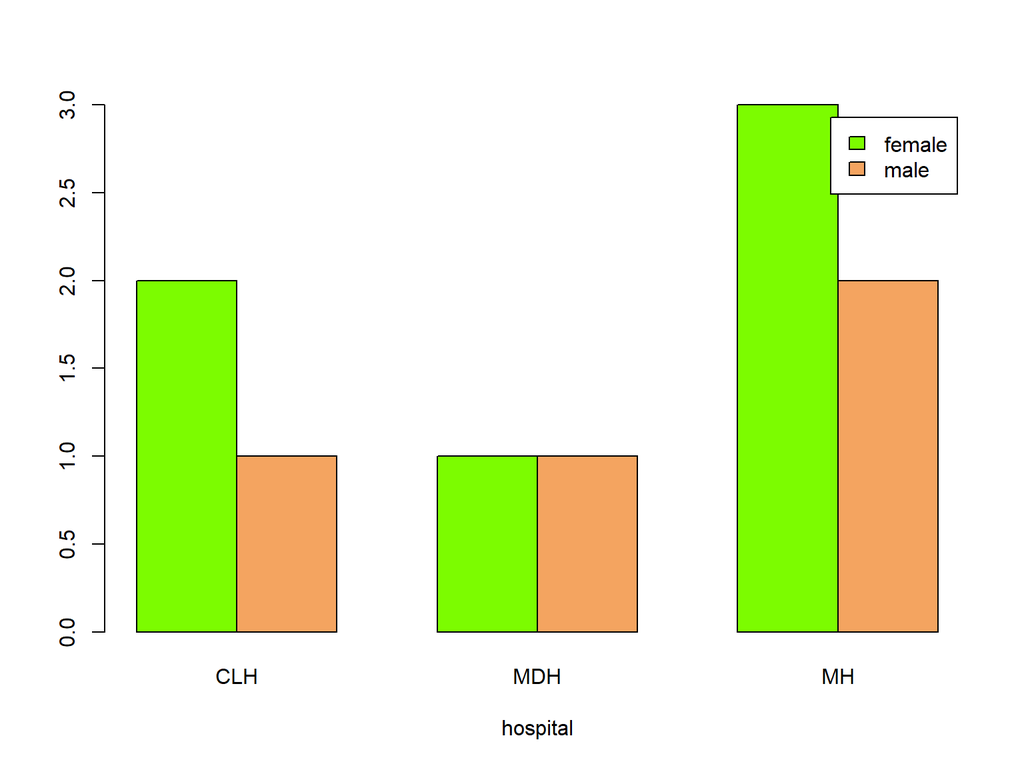

Fig 8. barplot customized

```r
tab <- table(bloodtest$gender, bloodtest$hospital)
barplot(tab,
        legend.text = TRUE,
        beside=TRUE,
        col=c("lawngreen", "sandybrown"),
        xlab="hospital")
```

> Create a bar plot of `ses` by `prog` in the data set `dat_csv`. Use the colors red, green, and blue to color the bars. Add a legend.

# Introducing `ggplot2` for graphics

Although Base `R` graphics functions are powerful and can be used to make publication-quality graphics, for new `R` users they are mostly ideal for creating quick, exploratory graphs.

Some common plotting features such as legends and multiple panels can be difficult to construct in base `R` graphics.

The package `ggplot2` is a better alternative to create complex, layered, and publication-quality graphics.

- `ggplot2` uses a structured *grammar of graphics* that provides an intuitive framework for building graphics layer-by-layer, rather than memorizing lots of plotting commands and options
- `ggplot2` graphics often require less work to make beautiful and eye-catching

> Please load the `ggplot2` package into your session now with `library()`.

# Basic syntax of a `ggplot2` plot

The basic specification for a `ggplot2` plot is to specify which variables are mapped to which aspects of the graph (called *aesthetics*) and then to choose a shape (called a *geom*) to display on the graph.

Although the full syntax of `ggplot2` is beyond the scope of this seminar, we can produce many plots with some variation of the following syntax:

```
ggplot(dataset, aes(x=xvar, y=yvar))
+ geom_function()
```

(Note that the package is named `ggplot2` while this function is called `ggplot()`)

That syntax uses the data in `dataset`, puts `xvar` on the x-axis, `yvar` on the y-axis, and uses `geom_function()` to produce shapes for the graph. For example `geom_point()` will produce a scatter plot, while `geom_bar()` produces bar plots.

Inside `aes()`, we can map more variables to graphical aspects of the plot, such as the `color`, `size` and `shape` of plotted objects.

For a much more detailed explanation of the grammar of graphics underlying `ggplot2`, see our [Introduction to ggplot2 seminar](https://stats.idre.ucla.edu/r/seminars/ggplot2_intro/).

# Layering graphics with `ggplot2`

To demonstrate how we layer graphics with the `ggplot2` package, we will be using the `dat_csv` data set.

Here we specify a scatter plot of math vs write.

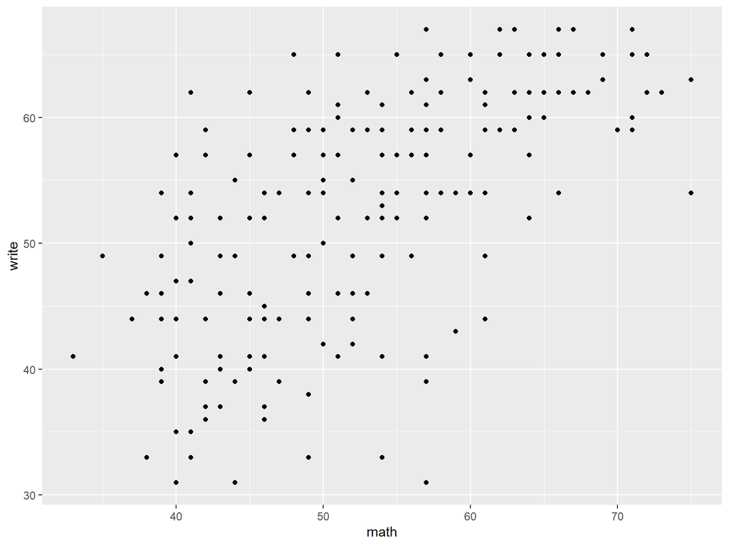

Fig 9a. Basic ggplot scatter plot

```r
# a scatterplot of math vs write
ggplot(data=dat_csv, aes(x=math, y=write)) +
   geom_point()
```

We add layers with `+`.

Here we add a layer that produces a regression line (and confidence interval) with `geom_smooth()`.

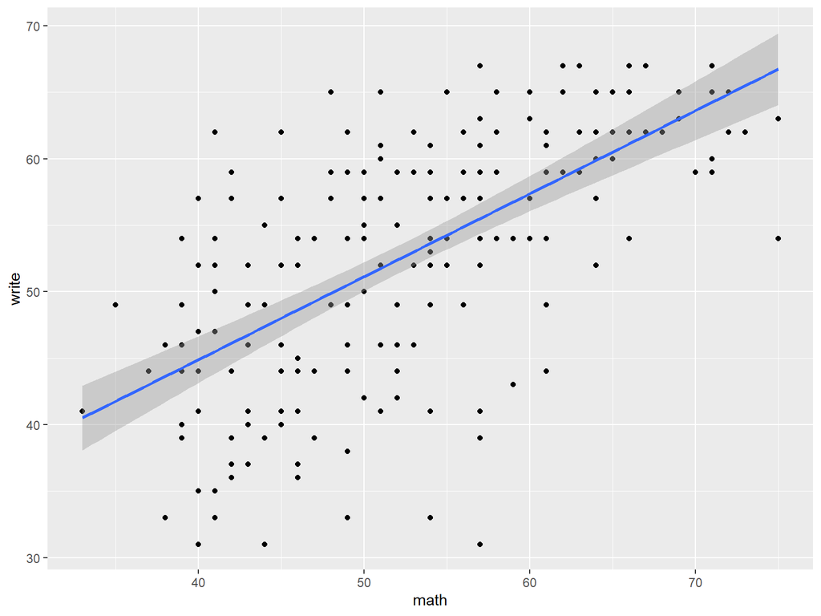

Fig 9b. best fit line

```r
# a scatterplot of math vs write with best fit line
ggplot(dat_csv, aes(x=math, y=write)) +
  geom_point() +
  geom_smooth(method="lm")
## `geom_smooth()` using formula 'y ~ x'
```

With `ggplot`, it is easy to link the `color`, `shape`, and `size` of the symbols to a variable.

Notice how `color` and `fill` will also group the data to produce separate plots.

Also notice that `ggplot` will insert legends for you by default.

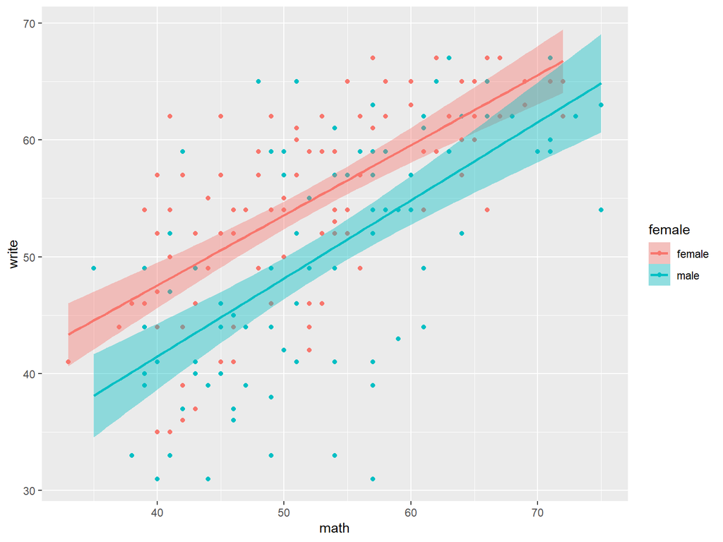

Fig 9c. colored by female

```r
# a scatterplot and best fit line, by gender
#  color affects the best fit line, fill affects the confidence intervals
ggplot(dat_csv, aes(x=math, y=write, color=female, fill=female)) +
  geom_point() +
  geom_smooth(method="lm")
## `geom_smooth()` using formula 'y ~ x'
```

We can easily make a panel of graphs with the function `facet_wrap`. Here we create separate plots for each program.

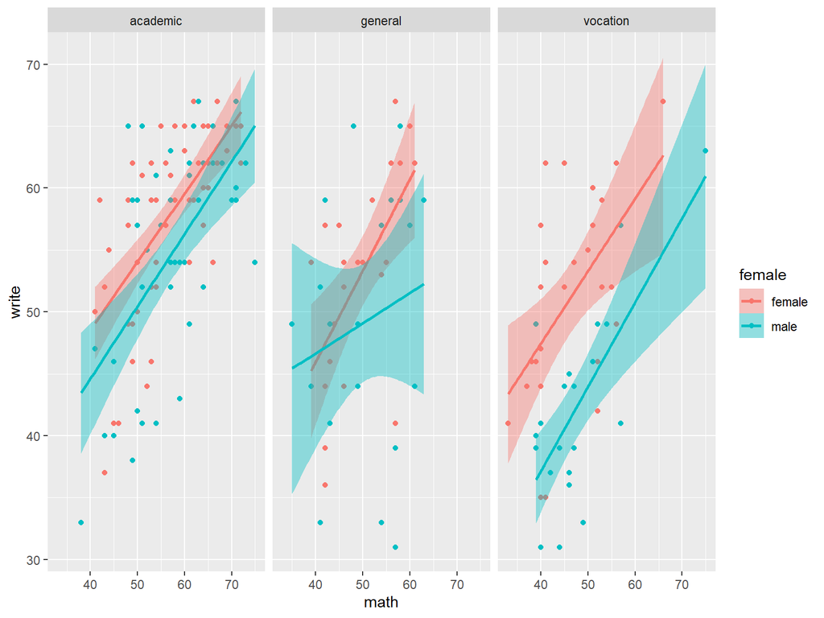

Fig 9d. paneled by prog

```r
# panel of scatterplot and best fit line, colored by gender, paneled by prog
ggplot(dat_csv, aes(x=math, y=write, color=female, fill=female)) +
  geom_point() +
  geom_smooth(method="lm") +
  facet_wrap(~prog)
## `geom_smooth()` using formula 'y ~ x'
```

`ggplot2` comes with several *complete theme* functions that change the overall appearance of the plot. We try 2 themes below:

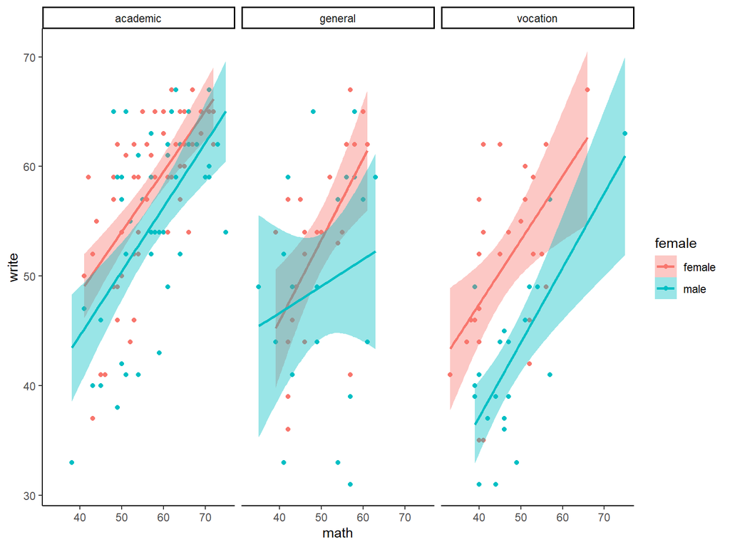

Fig 9e. classic theme

```r
# panel of scatterplot and best fit line, colored by gender, paneled by prog
ggplot(dat_csv, aes(x=math, y=write, color=female, fill=female)) +
  geom_point() +
  geom_smooth(method="lm") +
  facet_wrap(~prog) +
  theme_classic()
## `geom_smooth()` using formula 'y ~ x'
```

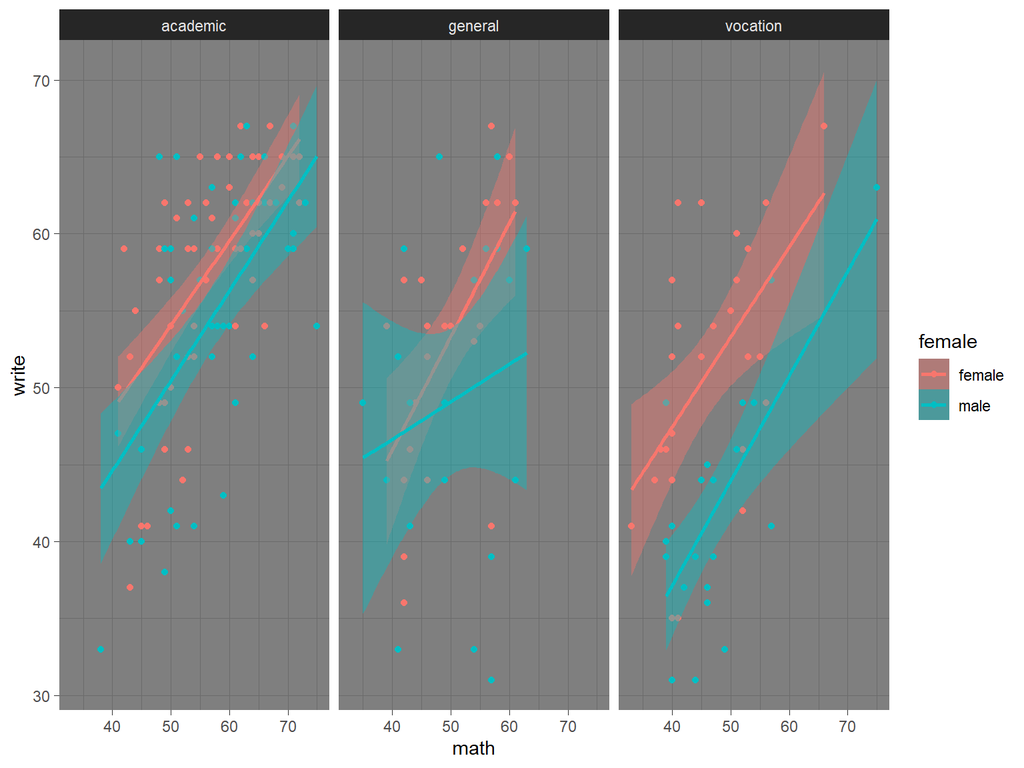

Fig 9f. dark theme

```r
# panel of scatterplot and best fit line, colored by gender, paneled by prog
ggplot(dat_csv, aes(x=math, y=write, color=female, fill=female)) +
  geom_point() +
  geom_smooth(method="lm") +
  facet_wrap(~prog) +
  theme_dark()
## `geom_smooth()` using formula 'y ~ x'
```

# ggplot2 exercise

> Use ggplot2 to make a scatter plot of `read` (x-axis) vs `write` (y-axis) from data set `dat_csv`. Color the dots by `ses`.  
> Now add a best fit line with `geom_smooth()`. Why are there 3 lines?

# Sharing your work

# RMarkdown

R Markdown allows users to create reproducible documents that weave narrative text together with R code and the output it produces when executed.

One of R Markdown’s great strengths is the variety of output documents it can produce such as HTML webpages, LaTeX documents, and Word documents.

These documents are dynamically generated – whenever we need to change code or data, we can simply update the R Markdown file, compile it, and the output will be automatically updated in the resulting docuemnt.

These documents can then be shared with an audience to provide the most up-to-date content.

For example, this slide-show was entirely produced in R Markdown. When R Markdown encounters the following code block in the file used to create this slide-show, `RMarkdown` embeds both the code block itself and the output (a graph) into the slide show:

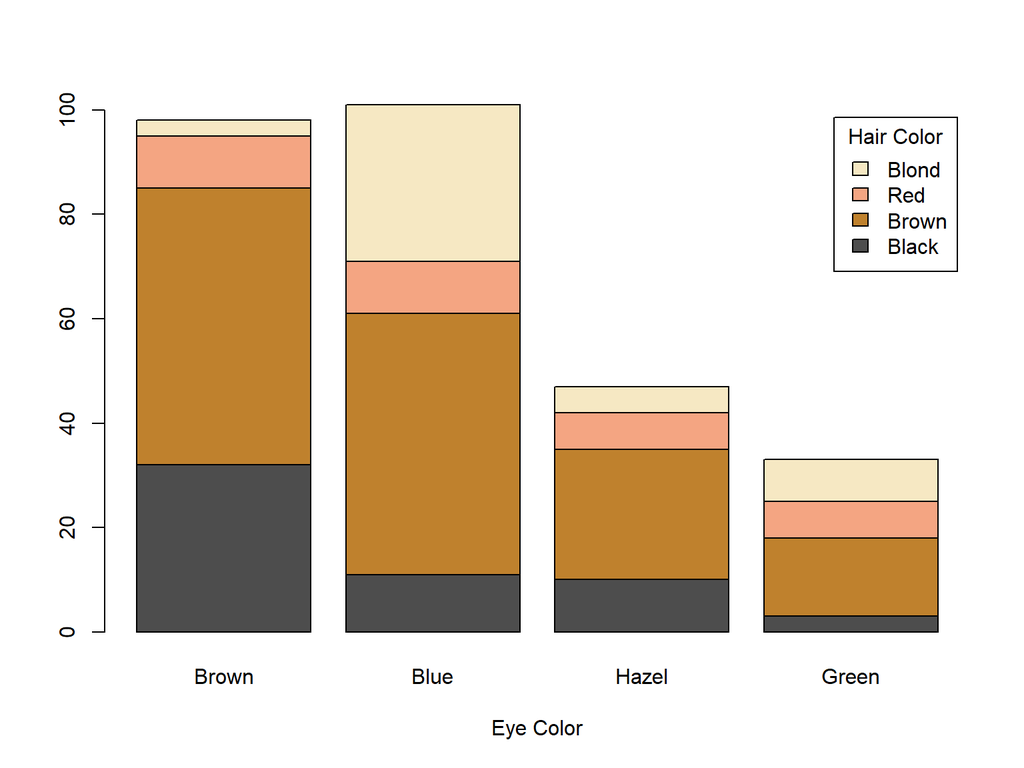

```r
barplot(HairEyeColor[,,1],
        col=c("#4d4d4d", "#bf812d", "#f4a582", "#f6e8c3"),
        legend.text=TRUE, xlab="Eye Color",
        args.legend=list(title="Hair Color"))
```

# R Markdown example

We can open a new Markdown file template through the `File` menu in RStudio.

> A. Choose `File` -> `New File` -> `R Markdown...`  
> B. Fill the `Title` field and `Author` fields with “Practice” and your name, respectively.  
> C. In the left menu, select `Document`, and for `Default Output Format` select option `HTML` (these are the defaults).  
> D. Click OK

R Markdown files typically use the extension `.Rmd` or `.rmd`

R Markdown files consist of 3 elements:

- YAML header: The header between `---` at the top; determines document type and overall appearance
- Markdown: code tags like `##` and `**` used to format text
- R code chunks: delineated by ``` and used to process data and output results

Once we are pleased with its contents, we can compile the R Markdown file and render it into its final output format by clicking the `Knit` button.

> Click the `Knit` button on your R Markdown document. Save the file with the name `myfirst.rmd`. Observe how each element in the R Markdown file becomes an element in the output document. *Note:* If `R` tells you that you need to install some packages before knitting, you must install the packages for `R` to output the documents.

# Markdown

Markdown is a *lightweight* markup language, which is a system of code tags used to format documents. Tags are used to define sections, change the appearance of text, build tables, link images, and so on.

Hypertext Markup Language (HTML) is a markup language designed to be used for web pages. The placement and appearance of text, images, frames, tables, and other elements can all be specified in HTML.

Markdown was originally designed to be a shorthand for HTML. For example in HTML, to italicize text, you enclose it in `<em> </em>`. In Markdown, you just enclose it in `* *`.

Some important Markdown tags:

- `*italics*` produces *italics*
- `**bold**` produces **bold**
- `# Header` produces a level 1 header (largest); add more `#` for lower level headers.

Do not insert spaces in between formatting tags and the text.

> Identify which text in your .rmd file has been formatted with Markdown tags.  
> Try changing the bolded word to italics.

> Add a level 4 header to the document called “Header 4”, knit the document, and compare its size to the other 2 headers.

# R Code chunks

For R Markdown files, R code is placed in code chunks that can be interleaved with the text of the document. All of the code chunks execute sequentially in one session when the `.rmd` file is rendered, so objects created in one chunk are available to all subsequent chunks.

R Markdown actually uses the package `knitr` to process the R code chunks.

[A large array of `knitr` options](https://yihui.name/knitr/options/) allows some control over the appearance of R code, text output and graphical output in the final document.

R code chunks are delimited by

````
```{r chunk_label,
options}
````

at the beginning and `` ``` `` at the end.

To create a code chunk:

- Use the shortcut `Ctrl + Alt + I` (`Cmd + Option + I` on Macs)
- Use the green Insert code button towards the top right of the script editor (will appear if the file extension is `.rmd`)
- Type out the tags

> A. Add an R code chunk using the keyboard shortcut or the Insert button to your R Markdown file.  
> B. Inside this code chunk, load the trees data set with the code `data("trees")`.  
> C. Produce a correlation matrix of the 3 variables in the `trees` data using the code `cor(trees)`.  
> D. Knit the .Rmd file and take note of the correlation matrix.

> E. Then, restrict the trees dataset to observations with `Height` greater than 80 by adding the code `trees <- subset(trees, trees$Height>80)` immediately after `data("trees")`.  
> F. Knit the .Rmd file again and notice how the correlation matrix changes.

# YAML header

The YAML header controls the overall appearance of the document, including the document type. It is located between the `---` at the top of the document.

The YAML (Yet Another Markup Language) header works with a program called pandoc, that can translate code tags between different document types.

The default document type is an `html_document`, which is typically a webpage. Other document types include:

- HTML slideshows
- LaTeX pdf documents
- Word documents
- PowerPoint presentations
- Books

> In the YAML header of your R Markdown file, change the `output:` to `word_document`.  
> Now change `output:` to `slidy_presentation`.  
> If you have LaTeX installed on your computer, you can change the `output:` to `pdf_document`.

# More help

# UCLA OARC R Seminars

- [R Data Management](https://stats.oarc.ucla.edu/r/seminars/r-data-management/)
- [R Markdown Basics](https://stats.oarc.ucla.edu/r/seminars/r-markdown-basics/)
- [R graphics with ggplot2](https://stats.oarc.ucla.edu/r/seminars/ggplot2_intro/)
- [Introduction to Regression in R](https://stats.oarc.ucla.edu/r/seminars/introduction-to-regression-in-r/)
- [Survival analysis in R](https://stats.oarc.ucla.edu/r/seminars/introduction-to-survival-analysis-in-r/)
- [Introduction to SEM in R](https://stats.oarc.ucla.edu/r/seminars/rsem/)

# Getting help online

- [UCLA OARC Statistical Methods and Data Analytics Website](http://www.ats.ucla.edu/stat/), our website with thousands of pages for help with statistical analysis
- [StackOverflow](http://www.stackoverflow.com/), a message board where R-related and statistics-related questions are answered
- [*R for Data Science*](http://r4ds.had.co.nz/), an online book written by the people who make RStudio and the tidyverse, that discusses how to use R for all steps of data analysis, with special emphasis on using the tidyverse

# Books on `R`

[Free online books to learn R](https://bookdown.org/)

[An extensive list of books (not necessarily free) about `R`](http://www.r-project.org/doc/bib/R-books.html)

# Thank you!